# Example: Yield to Maturity Calculation for a Note (Bond)

In this example, we will calculate the yield to maturity (YTM) of a note (bond) given its price, face value, coupon rate, and time to maturity. The YTM is the internal rate of return (IRR) of the bond, assuming it is held until maturity and all coupon payments are made as scheduled.

> **Motivation:** The YTM is a critical metric for bond investors as it allows for direct comparison of returns across bonds with different prices, coupons, and maturities, enabling informed investment decisions and portfolio optimization.

Let's get started! ___

## Setup, Data, and Prerequisites

We set up the computational environment by including the `Include.jl` file, loading any needed resources, such as sample datasets, and setting up any required constants.

> **Include:** The [include(...) function](https://docs.julialang.org/en/v1/base/base/#include) is a convenient way to load Julia code from another file. The `Include.jl` file is a Julia file that loads external packages, and various functions that we will use in the exercise. It checks for a `Manifest.toml` file; if it finds one, packages are loaded. Otherwise, packages are downloaded and then loaded.

Setup the environment:

```julia
include(joinpath(@__DIR__, "Include.jl")); # this sets up the environment, we'll do this all the time, on everything we do
```

For additional information on functions and types used in this material, see the [Julia programming language documentation](https://docs.julialang.org/en/v1/) and the [VLQuantitativeFinancePackage.jl documentation](https://github.com/varnerlab/VLQuantitativeFinancePackage.jl).

### Data

We are going to look at a hypothetical 10-year U.S. Treasury Note. The data for this security is encoded in [the `NamedTuple` data structure](https://docs.julialang.org/en/v1/base/base/#Core.NamedTuple). Let's start with a 10-year U.S. Treasury Note:

```julia
note_data = (
    T = "10-Year" |> securityterm,
    n = 2,
    par = 100.0,
    r̄ = 0.045, # 4.5%
    c̄ = 0.035,  # 3.5% coupon
);
```

Next, let's build an [instance of the `MyUSTreasuryCouponSecurityModel` type](https://varnerlab.github.io/VLQuantitativeFinancePackage.jl/dev/fixed/#VLQuantitativeFinancePackage.MyUSTreasuryCouponSecurityModel) using [a custom `build(...)` method](https://varnerlab.github.io/VLQuantitativeFinancePackage.jl/dev/fixed/#VLQuantitativeFinancePackage.build-Tuple%7BType%7BMyUSTreasuryCouponSecurityModel%7D,%20NamedTuple%7D), then we'll compute the auction price.

```julia
test_note_model = let

    # initialize -
    discount_model = DiscreteCompoundingModel();
    test_note = nothing; # initialize

    test_note = build(MyUSTreasuryCouponSecurityModel, (
        T = note_data.T,
        rate = note_data.r̄,
        coupon = note_data.c̄,
        λ = note_data.n,
        par = note_data.par,
    )) |> discount_model;

    test_note; # return
end;
```

What's the price of this note at auction?

```julia
test_note_model.price
```

```
92.01814381501211
```

## Let's compute the yield to maturity of the note

In this task, we will compute the yield to maturity of the 10-year U.S. Treasury Note using the `yieldtomaturity(...)` function that we implemented locally.

> **What is this function doing?** The `yieldtomaturity(...)` function uses the secant method to iteratively solve for the yield to maturity of a bond given its price, coupon payments, and time to maturity. The secant method is a root-finding algorithm that uses two initial guesses to approximate the root of a function. We use the default parameters in this example.

Let's play around with the parameters for the note and see how the yield to maturity changes.

```julia
Ȳ, solution_archive = let

    # initialize -
    TR = 5.0; # years to maturity
    price = (test_note_model.price)*1.0; # market price

    Y, YTM = yieldtomaturity(test_note_model; TR = TR, price=price);
    println("The yield to maturity of a U.S. Treasury Note with maturity in $(TR) years is approximately $(round(Y*100, digits=4))%")

    Y,YTM
end;
```

```
The yield to maturity of a U.S. Treasury Note with maturity in 5.0 years is approximately 5.3401%
```

**Curious:** How many iterations did it take to converge to a solution?

```julia
length(solution_archive)
```

```
6
```

### Discussion

1. Why does the yield to maturity of a coupon-bearing note (bond) increase as the time to maturity decreases, assuming the price remains constant?
2. If the time to maturity is fixed, how does a change in the price of the bond affect its yield to maturity?

### Why should we expect the secant method to work?

The secant method is a numerical technique used to find the roots of a function. In the context of calculating the yield to maturity (YTM) of a note (bond), we are trying to find the discount rate that equates the present value of the bond's future cash flows (coupon payments and face value at maturity) to its current market price.

> **Strictly decreasing function**: The $\texttt{NPV}(\bar{Y})$ function for a note (bond) is strictly decreasing with respect to the discount rate (YTM) (our variable $\bar{Y}$). This means that as the discount rate increases, the present value of the bond's cash flows decreases. Conversely, as the discount rate decreases, the present value of the bond's cash flows increases. This property ensures that there is a unique solution (root) for the YTM, as the NPV function will cross zero only once.

What does the NPV function look like for a note (bond)?

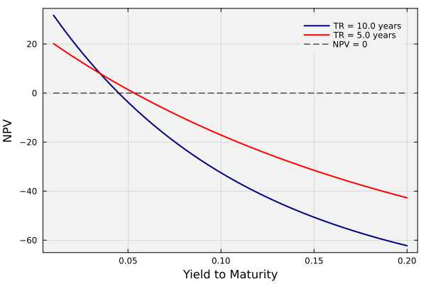

```julia
let

    # initialize -
    number_of_points = 100;
    Y = range(0.01, 0.20, length=number_of_points); # yield range
    TR = 10.0; # time to maturity
    VB = test_note_model.price;
    NPV_array_1 = [_net_present_value(test_note_model, y; TR = TR, price = VB) for y in Y];
    NPV_array_2 = [_net_present_value(test_note_model, y; TR=0.5*TR, price = VB) for y in Y];

    # break-even yield to maturity is where NPV = 0
    BEL = zeros(number_of_points);

    plot(Y,NPV_array_1, label="TR = $TR years", xlabel="Yield to Maturity", ylabel="NPV", legend=:topright, lw=2, c=:navy)
    plot!(Y,NPV_array_2, label="TR = $(0.5*TR) years", lw=2, c=:red)
    plot!(Y,BEL, label="NPV = 0", linestyle=:dash, color=:black)
    plot!(bg="gray95", background_color_outside="white", framestyle = :box, fg_legend = :transparent);
end
```

## Disclaimer and Risks

**This content is offered solely for training and informational purposes**. No offer or solicitation to buy or sell securities or derivative products or any investment or trading advice or strategy is made, given, or endorsed by the teaching team.

**Trading involves risk**. Carefully review your financial situation before investing in securities, futures contracts, options, or commodity interests. Past performance, whether actual or indicated by historical tests of strategies, is no guarantee of future performance or success. Trading is generally inappropriate for someone with limited resources, investment or trading experience, or a low-risk tolerance. Only risk capital that is not required for living expenses.

**You are fully responsible for any investment or trading decisions you make**. Such decisions should be based solely on evaluating your financial circumstances, investment or trading objectives, risk tolerance, and liquidity needs. ___